# Lab 6: Variable Selection and Prediction

MATH 4780 / MSSC 5780 Regression Analysis

Author

Mehdi Maadooliat

**NoteCourse data**

This lab uses objects in `regression_datasets.rda`. Put the `.qmd` file and `regression_datasets.rda` in the same folder before rendering or working through the lab.

## Learning goals

Compare best-subsets and stepwise procedures, evaluate candidate models using adjusted (R^2), Mallows’ (C_p), AIC, BIC, and PRESS/predicted (R^2), and recognize why automated selection cannot replace model checking.

```r
library(leaps)
library(dplyr)
```

## 1. Hospital manpower data

We use the same data as the 2026 variable-selection slides.

```r
fit_full <- lm(y ~ ., data = manpower)
summary(fit_full)
```

```
Call:
lm(formula = y ~ ., data = manpower)

Residuals:
   Min     1Q Median     3Q    Max
-611.9 -431.4  -70.8  332.6 1576.1

Coefficients:
             Estimate Std. Error t value Pr(>|t|)
(Intercept) 1962.9482  1071.3617    1.83    0.094 .
x1           -15.8517    97.6530   -0.16    0.874
x2             0.0559     0.0213    2.63    0.023 *
x3             1.5896     3.0921    0.51    0.617
x4            -4.2187     7.1766   -0.59    0.569
x5          -394.3141   209.6395   -1.88    0.087 .
---
Signif. codes:  0 '***' 0.001 '**' 0.01 '*' 0.05 '.' 0.1 ' ' 1

Residual standard error: 642 on 11 degrees of freedom
Multiple R-squared:  0.991, Adjusted R-squared:  0.987
F-statistic:  238 on 5 and 11 DF,  p-value: 8.07e-11
```

## 2. Best-subsets regression

```r
best <- leaps::regsubsets(y ~ ., data = manpower, nvmax = 5)
best_summary <- summary(best)

best_table <- data.frame(
  size = seq_along(best_summary$rsq),
  R2 = best_summary$rsq,
  adj_R2 = best_summary$adjr2,
  Cp = best_summary$cp,
  BIC = best_summary$bic
)

best_table
```

```
  size    R2 adj_R2    Cp   BIC
1    1 0.972  0.970 20.38 -55.2
2    2 0.987  0.985  4.94 -65.0
3    3 0.990  0.988  2.92 -67.1
4    4 0.991  0.988  4.03 -65.6
5    5 0.991  0.987  6.00 -62.8
```

```r
best_summary$which
```

```
  (Intercept)    x1    x2   x3    x4    x5
1        TRUE FALSE FALSE TRUE FALSE FALSE
2        TRUE FALSE  TRUE TRUE FALSE FALSE
3        TRUE FALSE  TRUE TRUE FALSE  TRUE
4        TRUE FALSE  TRUE TRUE  TRUE  TRUE
5        TRUE  TRUE  TRUE TRUE  TRUE  TRUE
```

Which model size is favored by adjusted (R^2), (C_p), and BIC? Do the criteria agree?

## 3. A function for PRESS and predicted (R^2)

For a fitted linear model,

```r
press_stats <- function(fit) {
  e <- resid(fit)
  h <- hatvalues(fit)
  press <- sum((e / (1 - h))^2)
  y <- model.response(model.frame(fit))
  sst <- sum((y - mean(y))^2)

  c(PRESS = press, R2_pred = 1 - press / sst)
}

press_stats(fit_full)
```

```
   PRESS  R2_pred
3.22e+07 9.35e-01
```

## 4. Compare the best model of each size

```r
which_mat <- best_summary$which

model_metrics <- lapply(seq_len(nrow(which_mat)), function(i) {
  selected <- names(which_mat[i, ])[which_mat[i, ]]
  selected <- setdiff(selected, "(Intercept)")
  form <- reformulate(selected, response = "y")
  fit <- lm(form, data = manpower)
  ps <- press_stats(fit)

  data.frame(
    size = length(selected),
    predictors = paste(selected, collapse = " + "),
    adj_R2 = summary(fit)$adj.r.squared,
    Cp = best_summary$cp[i],
    AIC = AIC(fit),
    BIC = BIC(fit),
    PRESS = unname(ps["PRESS"]),
    R2_pred = unname(ps["R2_pred"])
  )
})

bind_rows(model_metrics)
```

```
  size             predictors adj_R2    Cp AIC BIC    PRESS R2_pred
1    1                     x3  0.970 20.38 286 288 21841500   0.956
2    2                x2 + x3  0.985  4.94 275 278 17853441   0.964
3    3           x2 + x3 + x5  0.988  2.92 272 276 17846717   0.964
4    4      x2 + x3 + x4 + x5  0.988  4.03 273 278 28629419   0.942
5    5 x1 + x2 + x3 + x4 + x5  0.987  6.00 275 280 32195222   0.935
```

Which model would you choose if prediction were the primary goal? Is it the same model selected by BIC or (C_p)?

## 5. Forward, backward, and bidirectional stepwise AIC

Base R’s `step()` uses AIC by default.

```r
fit_null <- lm(y ~ 1, data = manpower)

forward_aic <- step(
  fit_null,
  scope = list(lower = fit_null, upper = fit_full),
  direction = "forward",
  trace = 0
)

backward_aic <- step(fit_full, direction = "backward", trace = 0)

both_aic <- step(
  fit_full,
  scope = list(lower = fit_null, upper = fit_full),
  direction = "both",
  trace = 0
)

formula(forward_aic)
```

```
y ~ x3 + x2 + x5
```

```r
formula(backward_aic)
```

```
y ~ x2 + x3 + x5
```

```r
formula(both_aic)
```

```
y ~ x2 + x3 + x5
```

Do all three search directions arrive at the same model? Why can greedy search procedures depend on the path they take?

## 6. Final model checking

Choose one candidate model and inspect it.

```r
final_fit <- both_aic
summary(final_fit)
```

```
Call:
lm(formula = y ~ x2 + x3 + x5, data = manpower)

Residuals:
   Min     1Q Median     3Q    Max
  -687   -381    -25    282   1630

Coefficients:
             Estimate Std. Error t value Pr(>|t|)
(Intercept) 1523.3892   786.8977    1.94    0.075 .
x2             0.0530     0.0201    2.64    0.021 *
x3             0.9785     0.1052    9.31  4.1e-07 ***
x5          -320.9508   153.1922   -2.10    0.056 .
---
Signif. codes:  0 '***' 0.001 '**' 0.01 '*' 0.05 '.' 0.1 ' ' 1

Residual standard error: 615 on 13 degrees of freedom
Multiple R-squared:  0.99,  Adjusted R-squared:  0.988
F-statistic:  432 on 3 and 13 DF,  p-value: 2.89e-13
```

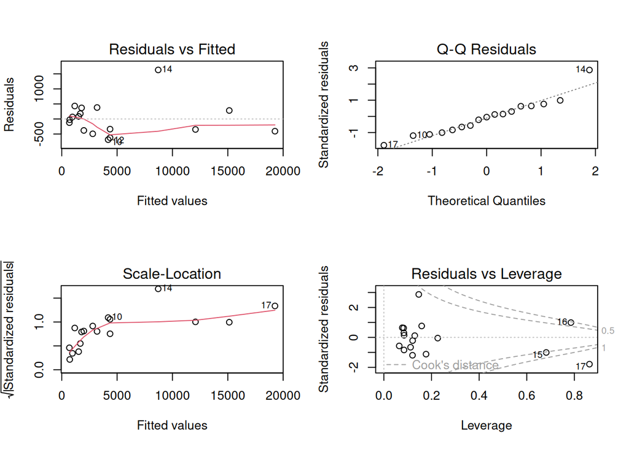

```r
par(mfrow = c(2, 2))
plot(final_fit)
```

```r
par(mfrow = c(1, 1))

press_stats(final_fit)
```

```
   PRESS  R2_pred
1.78e+07 9.64e-01
```

Would you report this model solely because an automated procedure selected it? What additional checks and subject-matter considerations are needed?

**TipImportant**

Variable selection is a **model-building aid**, not a substitute for scientific judgment, diagnostics, validation, or careful interpretation.